# Introdução a Linguagem R

Noso velho Gráfico

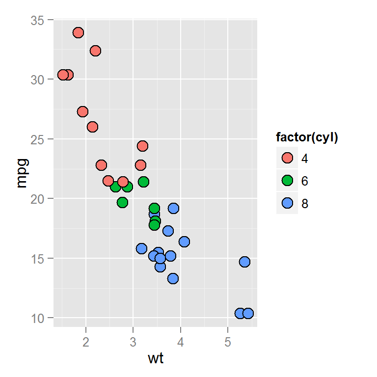

```r
g <- ggplot(mtcars,aes(x=wt,y=mpg,fill=factor(cyl)))
g <- g + geom_point(shape=21,size=4)
g
```

Facet + Temático

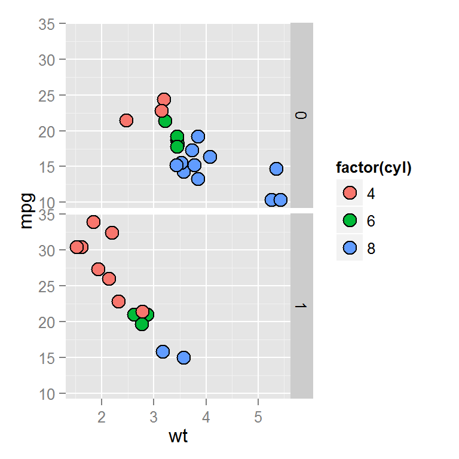

```r
g <- ggplot(mtcars,aes(x=wt,y=mpg,fill=factor(cyl)))
g <- g + geom_point(shape=21,size=4)
g <- g + facet_grid(am~.)
g
```

Derretendo dataset Construindo o dataframe

```r
set.seed(100)
tabErros<- seq(0,1,by=0.01)
erroM1<- sample(tabErros,20,replace = TRUE)
erroM2<- sample(tabErros,20,replace = TRUE)
exp <- seq(1,20)
df<- data.frame(exp,erroM1,erroM2)
df
```

```
##    exp erroM1 erroM2
## 1    1   0.31   0.54
## 2    2   0.26   0.71
## 3    3   0.55   0.54
## 4    4   0.05   0.75
## 5    5   0.47   0.42
## 6    6   0.48   0.17
## 7    7   0.82   0.77
## 8    8   0.37   0.89
## 9    9   0.55   0.55
## 10  10   0.17   0.28
## 11  11   0.63   0.49
## 12  12   0.89   0.93
## 13  13   0.28   0.35
## 14  14   0.40   0.96
## 15  15   0.77   0.70
## 16  16   0.67   0.89
## 17  17   0.20   0.18
## 18  18   0.36   0.63
## 19  19   0.36   0.99
## 20  20   0.69   0.13
```

Pedido do Orientador

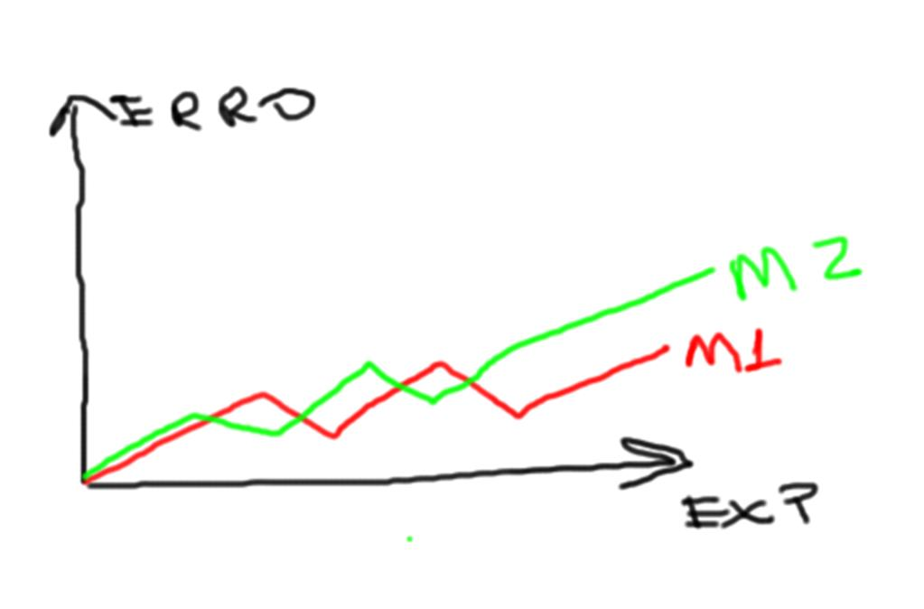

Resolve ?

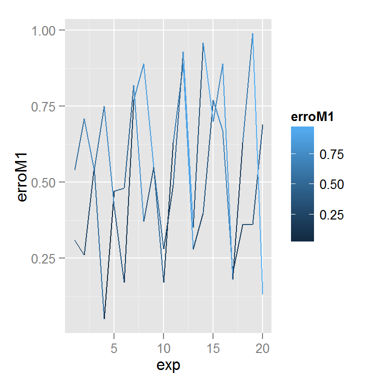

```r
g <- ggplot(df,aes(x=exp))
g <- g + geom_line(aes(y=erroM1,color=erroM1))
g <- g + geom_line(aes(y=erroM2,color=erroM2))
g
```

Derretendo o Data frame

```r
library(reshape2)
df.long<- melt(df,id="exp",measure=c("erroM1","erroM2"))
df.long
```

```
##    exp variable value
## 1    1   erroM1  0.31
## 2    2   erroM1  0.26
## 3    3   erroM1  0.55
## 4    4   erroM1  0.05
## 5    5   erroM1  0.47
## 6    6   erroM1  0.48
## 7    7   erroM1  0.82
## 8    8   erroM1  0.37
## 9    9   erroM1  0.55
## 10  10   erroM1  0.17
## 11  11   erroM1  0.63
## 12  12   erroM1  0.89
## 13  13   erroM1  0.28
## 14  14   erroM1  0.40
```

[output cut: 26 more lines]

Agora…

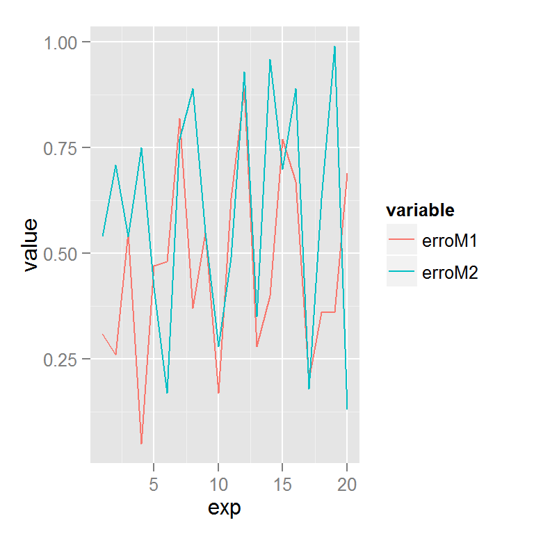

```r
g <- ggplot(df.long,aes(x=exp,y=value,color=variable))
g <- g + geom_line(aes())
g
```

Agora… em preto e branco

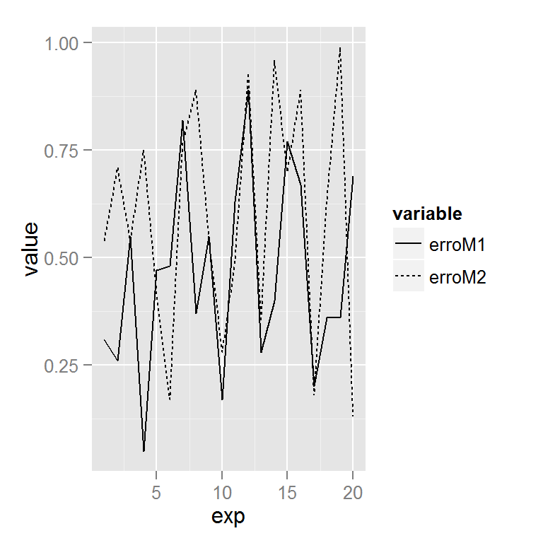

```r
g <- ggplot(df.long,aes(x=exp,y=value,linetype=variable))
g <- g + geom_line()
g
```

```
## stat_bin: binwidth defaulted to range/30. Use 'binwidth = x' to adjust this.
## stat_bin: binwidth defaulted to range/30. Use 'binwidth = x' to adjust this.
```

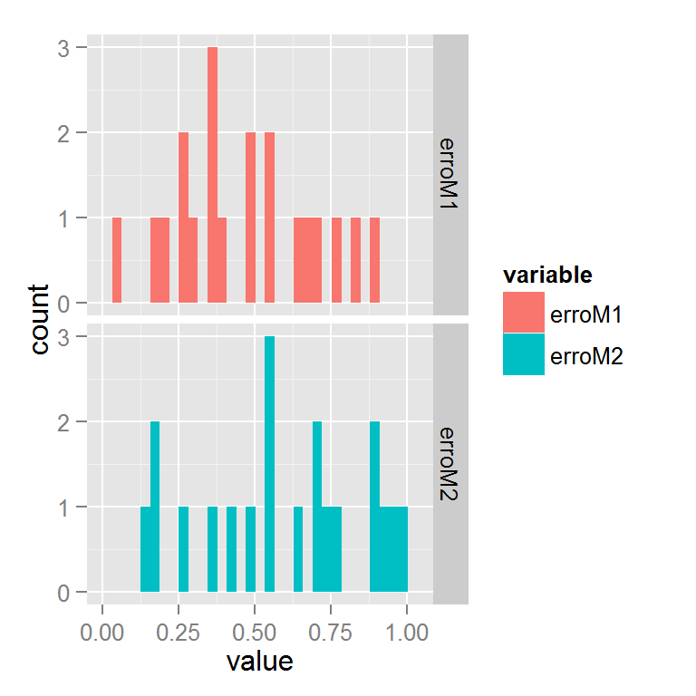

```r
g <- ggplot(df.long,aes(x=value,fill=variable))
g <- g + geom_histogram()
g<- g + facet_grid(variable~.)
g
```

Legendas

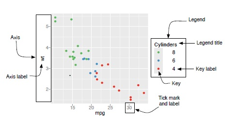

Temas Vs Legendas

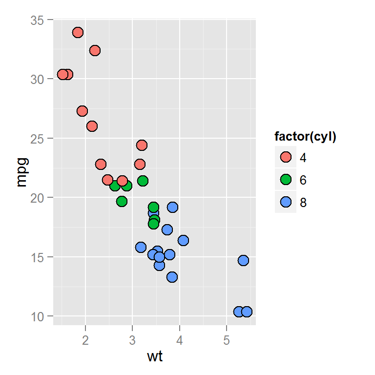

```r
g <- ggplot(mtcars,aes(x=wt,y=mpg,fill=factor(cyl)))+geom_point(shape=21,size=4)
g
```

Mudando as cores

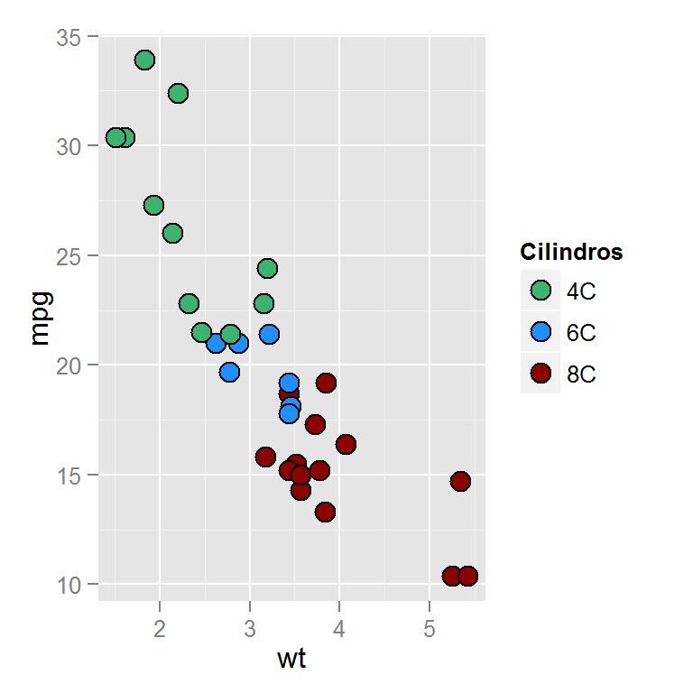

```r
g <- g + scale_fill_manual(name="Cilindros",
                             labels=c("4C","6C","8C"),
                             values=c('mediumseagreen','dodgerblue1','darkred'))
g
```

Legendas - Posição

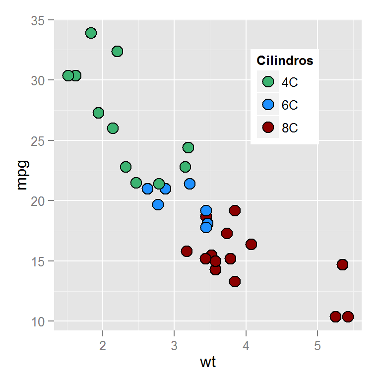

```r
g<-g+ theme(legend.position=c(0.75,0.75))
g
```

Molduras

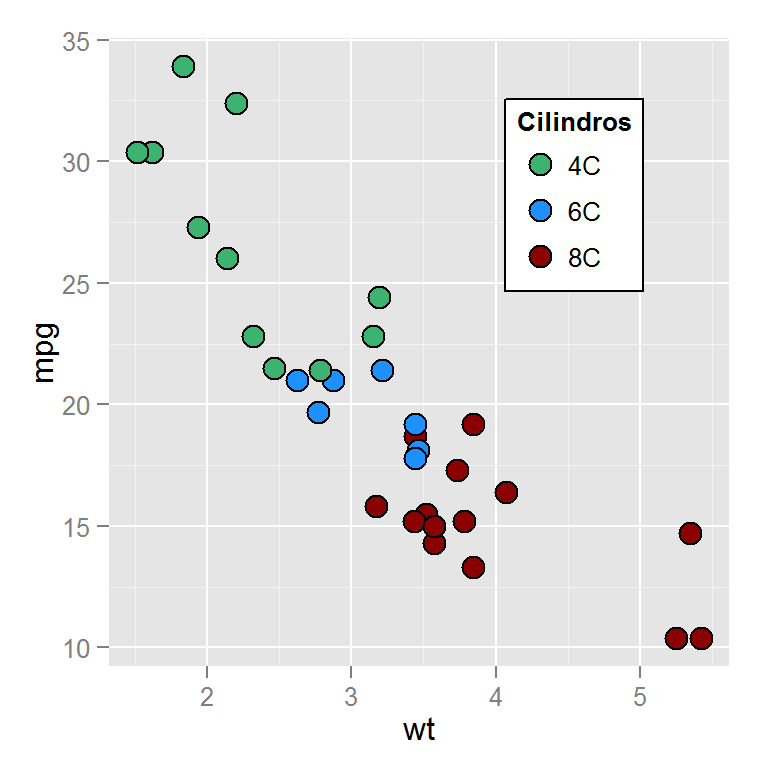

```r
g<-g+ theme(legend.key = element_rect(fill = "white",color='white'))
g<-g+ theme(legend.background = element_rect(colour = "black",fill="white"))
g
```

Formatando Textos

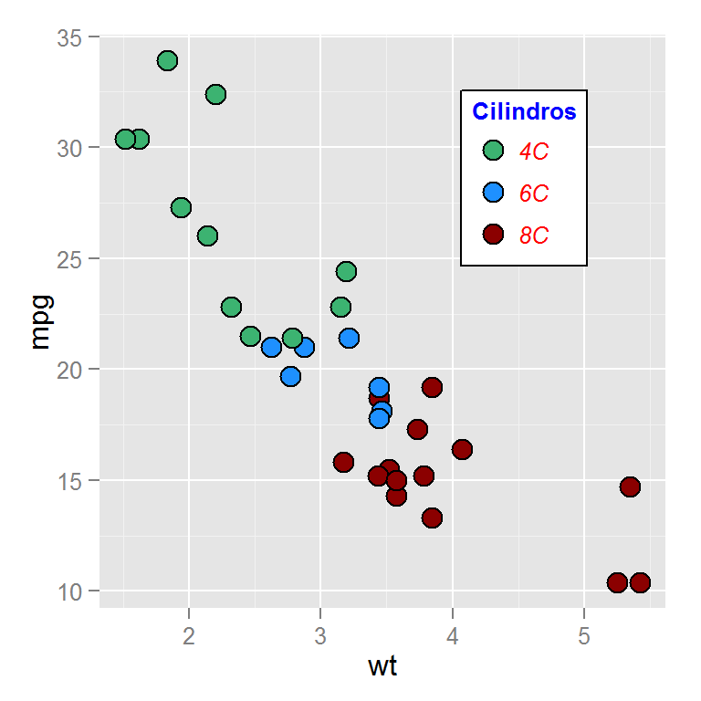

```r
g<-g+ theme(legend.title = element_text(color="blue",face="bold"))
g<-g+ theme(legend.text = element_text(colour = "red",face="italic"))
g
```

# Caret Package

Aprendizagem de Máquina com Caret

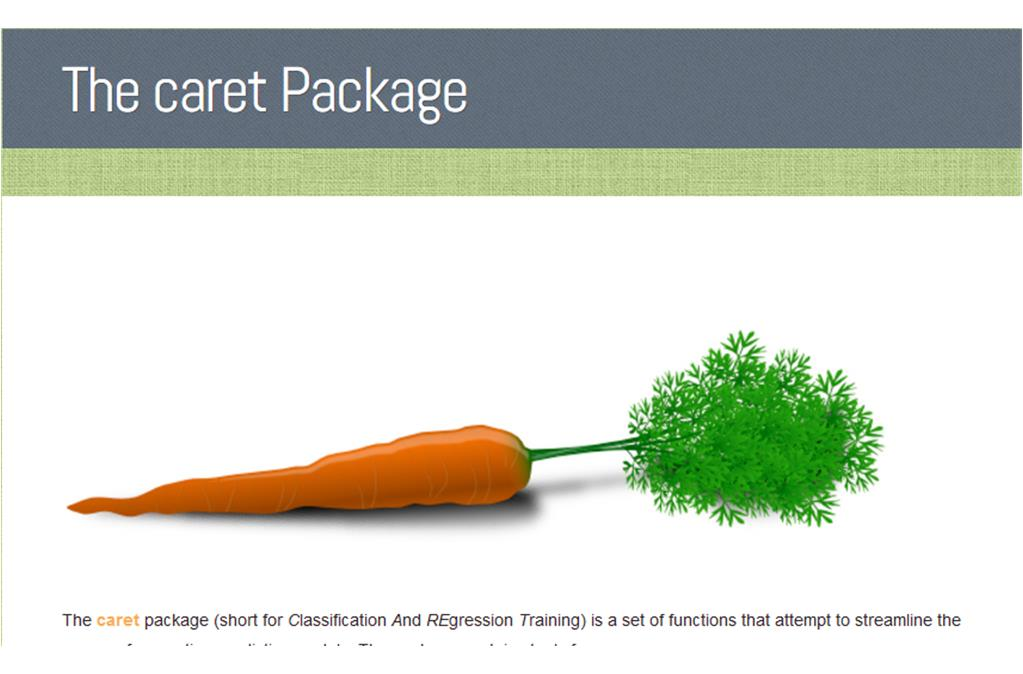

## Knn e SVM

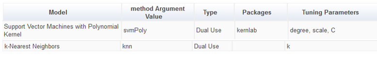

```r
library(caret)
  knnTrainControl <- trainControl(method = "repeatedcv",
                                  number = 10,
                                  repeats = 5,
                                  returnResamp = "all"
                                  )
  set.seed(100)
  knnModel<-train(mpg ~.,
                  data=mtcars,
                  preProcess = c("center","scale"),
                  method = "knn",
                  trControl = knnTrainControl,
                  tuneGrid = data.frame(.k=c(1,3,5,7,9,11))
                  )
```

```r
knnModel
```

```
## k-Nearest Neighbors
##
## 32 samples
## 10 predictors
##
## Pre-processing: centered, scaled
## Resampling: Cross-Validated (10 fold, repeated 5 times)
##
## Summary of sample sizes: 28, 30, 28, 28, 28, 29, ...
##
## Resampling results across tuning parameters:
##
##   k   RMSE  Rsquared  RMSE SD  Rsquared SD
##   1   2.66  0.92      1.37     0.118
##   3   2.97  0.847     1.3      0.231
##   5   3.11  0.859     1.29     0.223
##   7   3.16  0.859     1.2      0.193
##   9   3.14  0.842     1.2      0.2
##   11  3.15  0.844     1.36     0.183
##
## RMSE was used to select the optimal model using  the smallest value.
## The final value used for the model was k = 1.
```

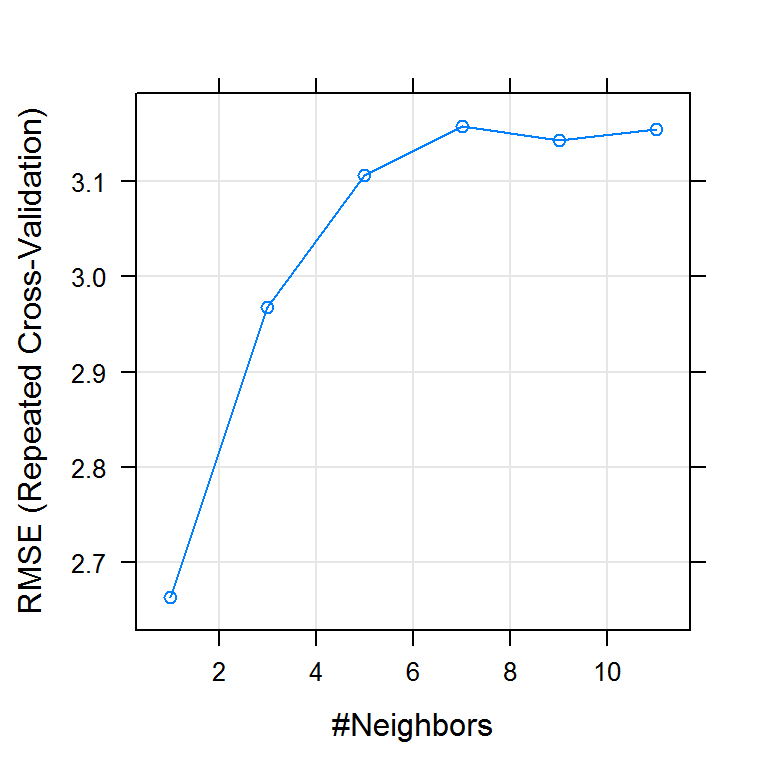

```r
plot(knnModel)
```

```r
library(caret)
library(kernlab)
#Ajustando parametros de tuning
svmGrid <- expand.grid(.scale = c(0.01,.005),
                           .degree = c(1,2),
                           .C=c(2,2^8,2^10))

svmTrainControl <- trainControl(method = "cv",
                                 number = 10,
                                 returnResamp = "all")
set.seed(100)

svmPolyModel<-train(mpg ~ .,
                      data = mtcars,
                      preProcess = c("center","scale"),
                      method="svmPoly",
                      tuneGrid=svmGrid,
                      trControl= svmTrainControl
)
```

```r
svmPolyModel
```

```
## Support Vector Machines with Polynomial Kernel
##
## 32 samples
## 10 predictors
##
## Pre-processing: centered, scaled
## Resampling: Cross-Validated (10 fold)
##
## Summary of sample sizes: 28, 30, 28, 28, 28, 29, ...
##
## Resampling results across tuning parameters:
##
##   scale  degree  C     RMSE  Rsquared  RMSE SD  Rsquared SD
##   0.005  1       2     2.81  0.933     1.9      0.079
##   0.005  1       256   3.13  0.888     1.24     0.191
##   0.005  1       1020  3.34  0.872     1.33     0.195
##   0.005  2       2     2.78  0.928     1.67     0.0864
##   0.005  2       256   3.12  0.863     1.12     0.265
##   0.005  2       1020  3.41  0.855     1.09     0.275
##   0.01   1       2     2.79  0.928     1.69     0.087
##   0.01   1       256   3.26  0.881     1.3      0.193
##   0.01   1       1020  3.41  0.859     1.36     0.198
##   0.01   2       2     2.61  0.927     1.28     0.0913
##   0.01   2       256   3.42  0.861     1.03     0.277
##   0.01   2       1020  4.05  0.806     1.38     0.261
##
## RMSE was used to select the optimal model using  the smallest value.
## The final values used for the model were degree = 2, scale = 0.01 and C
##  = 2.
```

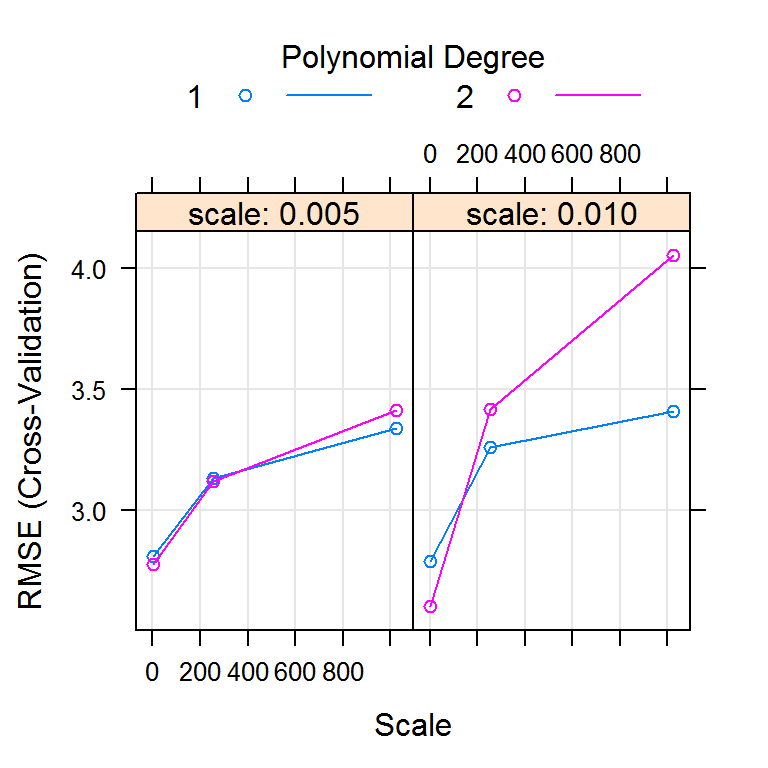

```r
plot(svmPolyModel)
```

Evitando Loops

Calculando a média de um vetor

```r
notas1<-c(4.0,6.0,8.0,10,8.8,9.2)
mean(notas1)
## [1] 7.666667
```

Calculando a média no Data Frame

```r
alunos<-c("aluno1","aluno2","aluno3","aluno4","aluno5","aluno6")
notas1<-c(4.0,6.0,8.0,10,8.8,9.2)
notas2<-c(5.0,7.2,8.4,9.8,8.2,7.2)
dfNotas<-data.frame(alunos,notas1,notas2)
mean(dfNotas[,2:3])
## Warning in mean.default(dfNotas[, 2:3]): argument is not numeric or
## logical: returning NA
## [1] NA
```

Solução usando Vectorize

```r
vmean<-Vectorize(mean)
vmean(dfNotas[,2:3])
##   notas1   notas2
## 7.666667 7.633333
```

Solução com apply

```r
apply(dfNotas[,2:3],2,mean)
##   notas1   notas2
## 7.666667 7.633333
```

média por aluno ?

```r
dfNotas
##   alunos notas1 notas2
## 1 aluno1    4.0    5.0
## 2 aluno2    6.0    7.2
## 3 aluno3    8.0    8.4
## 4 aluno4   10.0    9.8
## 5 aluno5    8.8    8.2
## 6 aluno6    9.2    7.2
```

Calculando a média por Aluno

```r
apply(dfNotas[,2:3],1,mean)
## [1] 4.5 6.6 8.2 9.9 8.5 8.2
```

Desafio Conhecendo a função sweep

```r
m<-matrix(c(1,2,3,4,5,6),3,2)
m
##      [,1] [,2]
## [1,]    1    4
## [2,]    2    5
## [3,]    3    6
```

Tirando 0.5 de cada linha

```r
sweep(m,2,c(0.5,0.5),"-")
##      [,1] [,2]
## [1,]  0.5  3.5
## [2,]  1.5  4.5
## [3,]  2.5  5.5
#1 para linhas e 2 para colunas
```

Normalizando M

```r
m
##      [,1] [,2]
## [1,]    1    4
## [2,]    2    5
## [3,]    3    6
```

Você consegue explocar o código abaixo ?

```r
m1 <- sweep(m,2,apply(m,2,min),"-")
m1 <- sweep(m1,2,apply(m,2,max)-apply(m,2,min),"/")
m1
##      [,1] [,2]
## [1,]  0.0  0.0
## [2,]  0.5  0.5
## [3,]  1.0  1.0
```

Utilizando Reduce

```r
maior <- function(a,b){
   if (a>b){
     a
   }
   else{
     b
   }
}
maior(10,12)
## [1] 12
a<-c(1,2,3,5,6,7,8,9,16)
Reduce(maior,a)
## [1] 16
```